# Exploring the BRFSS data

## Setup

### Load packages

```r
library(ggplot2)
library(dplyr)
library(RColorBrewer)
library(knitr)
library(corrplot)
```

### Load data

```r
load("C:/Users/user/Downloads/_384b2d9eda4b29131fb681b243a7767d_brfss2013 (1)")
```

## Part 1 : DATA

1. Data : The Behavioral Risk Factor Surveillance system(BRFSS) is the nation’s premier system of health-related telephone survey. It is collected by U.S. residents in all 50 states. The number of interviewee is more than 400,000 each year. By collecting behavioral health risk data at the state and local level, BRFSS has become a powerful tool for targeting and building health promotion activities. As a result, BRFSS users have increasingly demanded more data and asked for more questions on the survey.

## Part 2 : Research Questions

**Research quesion 1:** What is the distribution of the observations in the sample look like in terms of levels of general health? Is there any noticeable differences between the distributions by education levels?

**Research quesion 2:** Does high blood cholesterol results in more hearthstrokes in North Carolina? Are heartstrokes correlated to exercises, doctor visits and blood cholesterol high?

**Research quesion 3:** Have people with low income the same percentage of Fair and Poor Health as all the samples of this data? Then are there different between education levels of lower income?

## Part 3 : Exploratory data analysis

### Research quesion 1:

One most appealing question is to get to know people’s health status by studying a random sample out of the total population. Here we will study the general health conditions by education levels.

```r
health1 <- brfss2013 %>%
  filter(!is.na(brfss2013$genhlth), !is.na(brfss2013$educa), !is.na(brfss2013$X_age65yr)) %>%
  group_by(genhlth, educa) %>%
  summarize(n = n())
health2 <- brfss2013 %>%
  filter(!is.na(brfss2013$genhlth), !is.na(brfss2013$educa), !is.na(brfss2013$X_age65yr)) %>%
  group_by(genhlth, educa, X_age65yr) %>%
  summarize(n = n()) %>%
  mutate(pct_genhlth = n/sum(n),
         posn_pct = cumsum(pct_genhlth)-0.5*pct_genhlth)
```

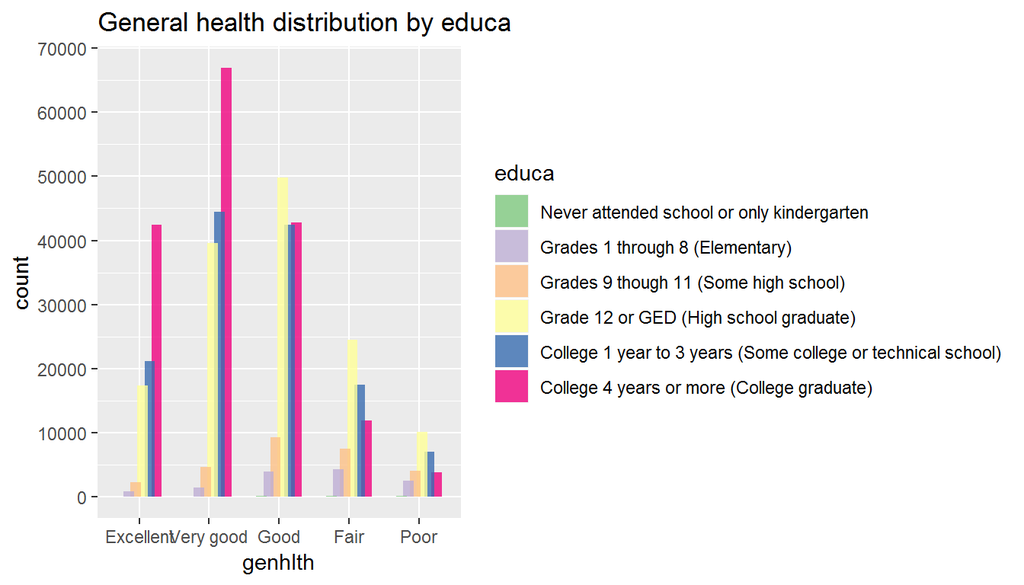

```r
ggplot(health1, aes(x = genhlth, y = n, fill = educa)) +
  geom_bar(stat = "identity", position = position_dodge(0.6), alpha = 0.8) +
  scale_fill_brewer(palette = "Accent")+
  scale_y_continuous("count", breaks = seq(0, 100000, by = 10000)) +
  labs(title = "General health distribution by educa")
```

In the bar chart above, we know that College 4 years or more(College graduate) level is in good health. And among those who are under-normal in health, the percentage of high school graduates is the highest.

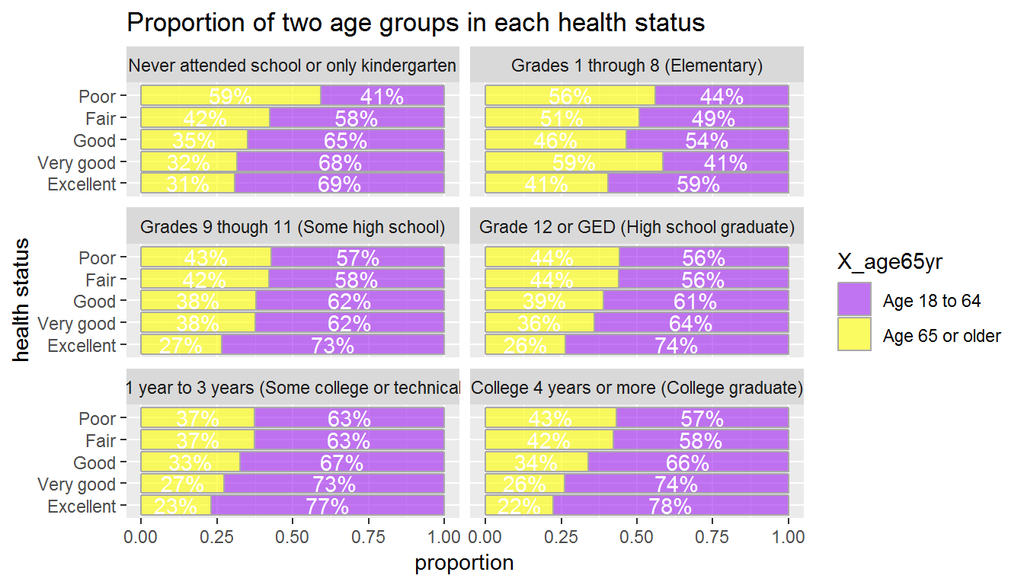

```r
ggplot(health2, aes(x = genhlth, y = pct_genhlth, fill = X_age65yr)) +
  geom_bar(stat = "identity", alpha = 0.6, col = "dark grey") +
  scale_fill_manual(values = c("purple", "yellow")) +
  facet_wrap(~educa, ncol = 2) +
  geom_text(aes(label = paste0(sprintf("%.0f", pct_genhlth*100),"%"), y=1-posn_pct), col = "white") +
  labs(title = "Proportion of two age groups in each health status") +
  scale_x_discrete("health status") +
  scale_y_continuous("proportion") +
  coord_flip()
```

Let’s drill down a little bit further by taking the age into consideration. For almost all levels of education, people under 64 are in higher health than those over 65.

### Research quesion 2:

Does high blood cholesterol results in more hearthstrokes in North Carolina? Are heartstrokes correlated to exercises, doctor visits and blood cholesterol high?

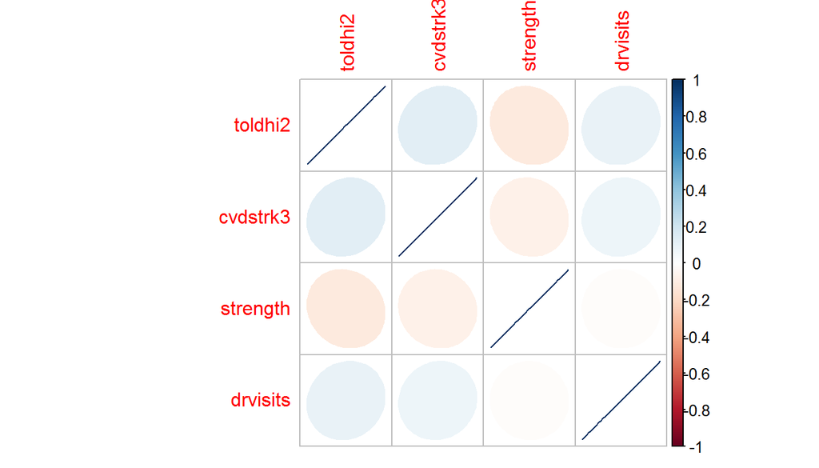

```r
heart <- brfss2013 %>%
  filter(!is.na(toldhi2), !is.na(cvdstrk3), !is.na(drvisits), !is.na(strength), X_state=="North Carolina") %>%
  select(toldhi2,cvdstrk3,strength, drvisits)

heart$toldhi2 <- ifelse(heart$toldhi2=="Yes",1,0)
heart$cvdstrk3 <- ifelse(heart$cvdstrk3=="Yes",1,0)

korelace<-cor(heart)
corrplot(korelace, method="ellipse")
```

This looks like there is weak correlation between high blood cholesterol and diagnosed stroke. Also it looks like there is weak correlation between high blood cholesterol and number of doctor visits, and very weak correlation between number of doctor visits and diagnosed stroke, but no correlation between number of doctor visits and excercise(strength). Even more! There is weak negative correlation between excercise(strength) and high blood cholesterol, but very weak negative correlation between excercise(strength) and diagnosed stroke.

### Research quesion 3:

```r
qs1 <- brfss2013 %>%
  group_by(X_incomg, X_rfhlth) %>%
  tally() %>%
  group_by(X_incomg) %>%
  mutate(pct = n/sum(n))
```

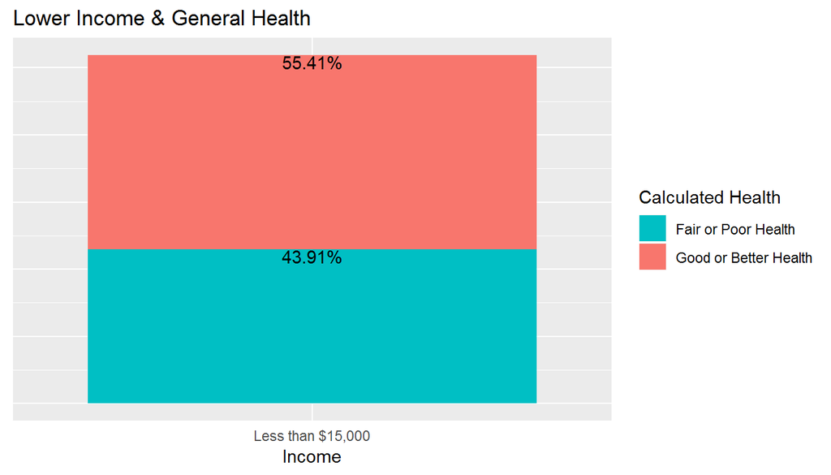

```r
p1 <- ggplot(na.omit(subset(qs1, X_incomg == "Less than $15,000")),
             aes(x=X_incomg, y=n, fill=X_rfhlth)) +
  geom_bar(stat = "identity", position = "stack") +
  geom_text(aes(label=paste0(round(pct*100,2),"%")), position = position_stack(), vjust = 1) +
  labs(title = "Lower Income & General Health", x = "Income") +
  theme(axis.text.y=element_blank(),
        axis.ticks=element_blank(),
        axis.title.y=element_blank()) +
  scale_fill_discrete(name="Calculated Health",
                      breaks = c("Fair or Poor Health", "Good or Better Health"))
p1
```

Then we will find the answer for second part of the research question.

```r
qs1_2 <- brfss2013 %>%
  group_by(X_incomg, educa, X_rfhlth) %>%
  tally() %>%
  group_by(X_incomg, educa) %>%
  mutate(pct = n/sum(n))
```

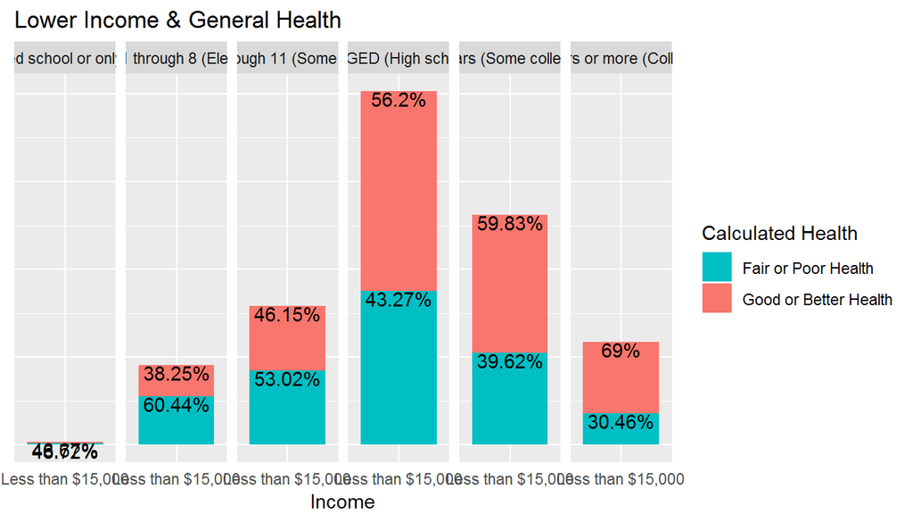

```r
p2 <- ggplot(na.omit(subset(qs1_2, X_incomg == "Less than $15,000")),
             aes(x=X_incomg, y=n, fill=X_rfhlth)) +
  geom_bar(stat = "identity", position = "stack") +
  geom_text(aes(label=paste0(round(pct*100,2),"%")), position = position_stack(), vjust = 1) +
  facet_grid(.~educa) +
  labs(title = "Lower Income & General Health", x = "Income") +
  theme(axis.text.y=element_blank(),
        axis.ticks=element_blank(),
        axis.title.y=element_blank()) +
  scale_fill_discrete(name="Calculated Health",
                      breaks = c("Fair or Poor Health", "Good or Better Health"))
p2
```

In High education level, even though lower income, the percentage of ‘Good or Better health’ is high than the percentage of ‘Fair or Poor health’. But in low education level, the percentage of ‘Fair or Poor health’ is high than the percentage of ‘Good or Better health’.